# Pruebas

# Análisis de series de tiempo económicas

Función de autocorrelación sobre ruido blanco. Se puede ver que la serie está centrada en cero y que su autocorrelación sólo tiene una correlación alta para el *lag* 0, mientras que es baja para el resto de los puntos.

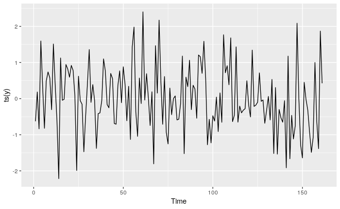

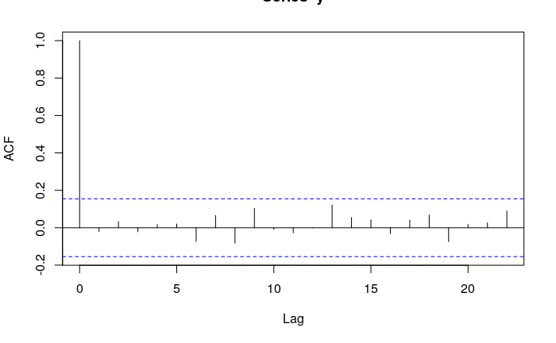

Autocorrelación sobre una función periodica (seno). Puede verse la fuerte autocorrelación entre los ciclos.

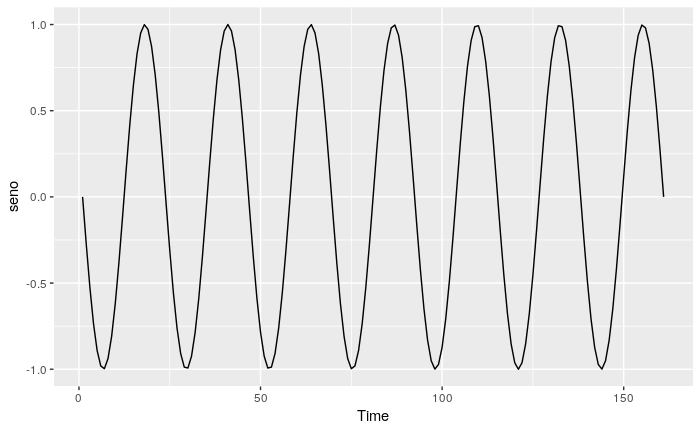

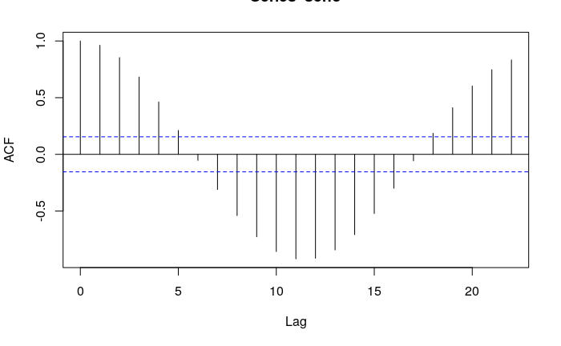

## Autocorrelación sobre la tasa de largo plazo

El siguiente grafico muestra la serie de la tasa de interés de largo plazo de los EE.UU. desde el año 1857 como una serie anual.

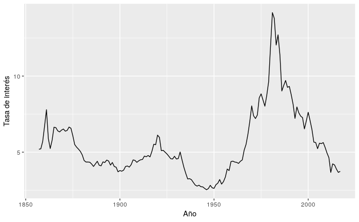

Hay que sacarle la tendencia a la serie

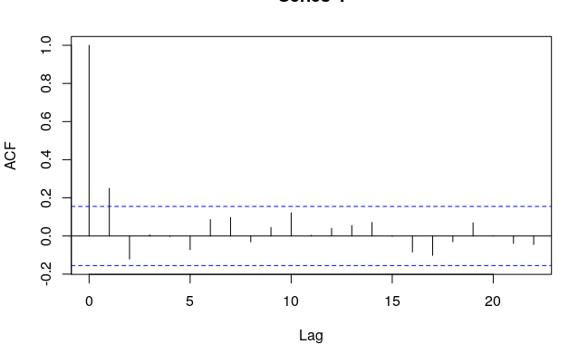

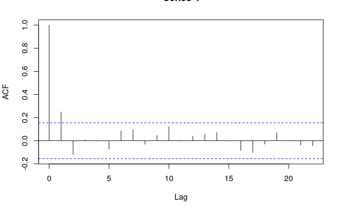

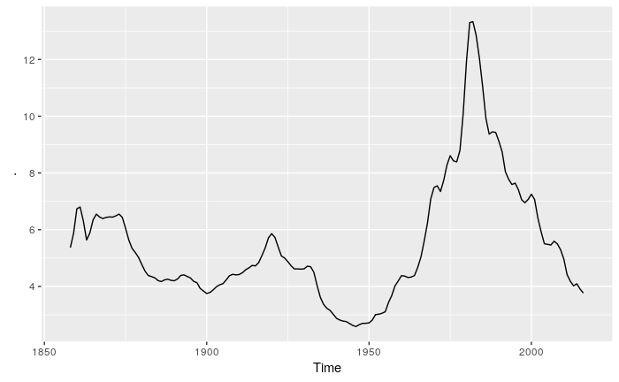

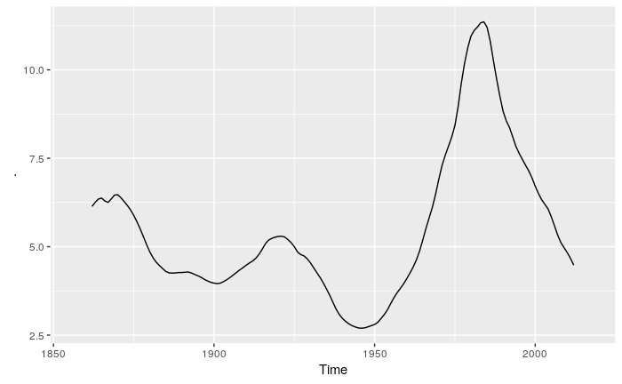

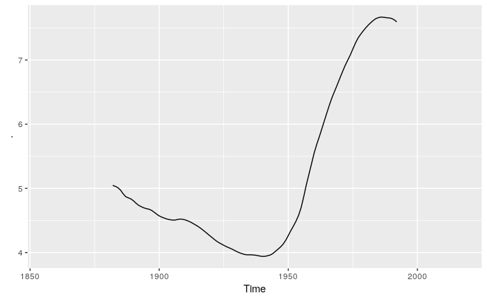

En la siguente transformación de fourier de la serie de la tasa de interés de largo plazo, se puede observar una componente de largo plazo de gran amplitud.

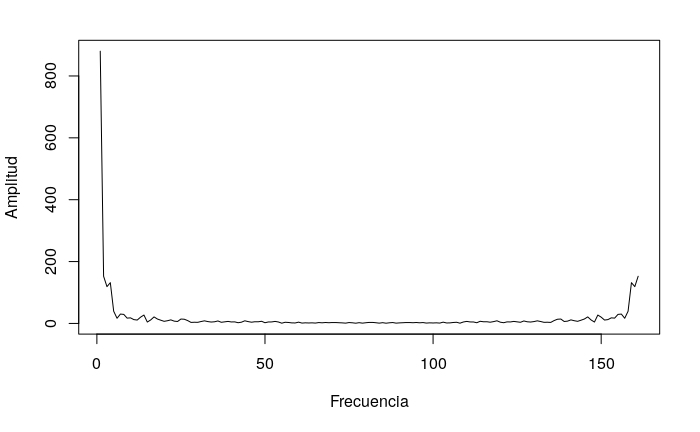

Para que la transformada de Fourier no quede distorsionada por la tendencia, se debe centrar la serie primero. Para ello, luego de varias pruebas, usamos una media movil de 10 lags, por capturar las tendencias de un plazo no tan largo en el periodo considerado y que obtiene un suavizado aceptable. Vemos cómo queda a continuación las diferentes medias móviles consideradas, todas sin centrar. Los órdenes más grandes de media móvil suavizan mucho la serie, aunque esto es subjetivo.

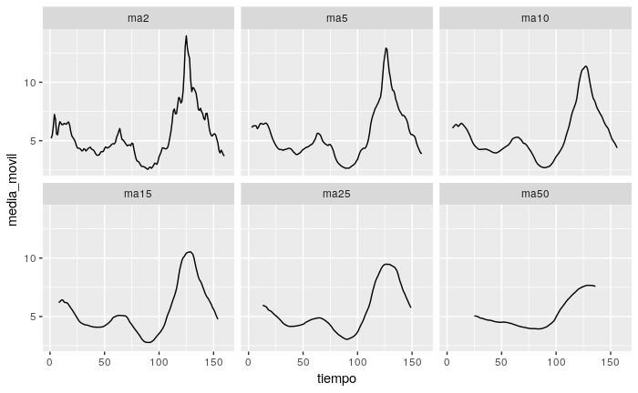

Centrando la serie:

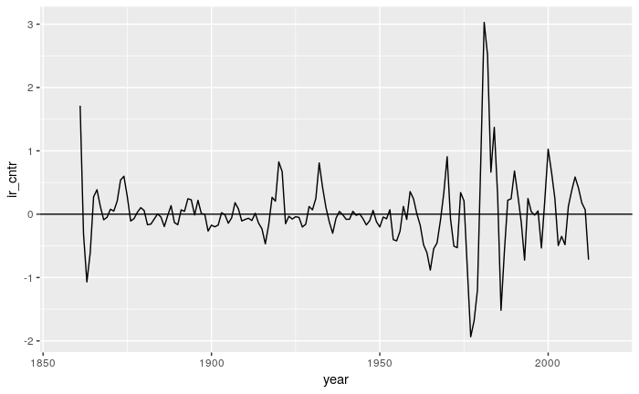

Veamos cómo queda la descomposición de la serie de acuerdo con las transformaciones de Fourier.

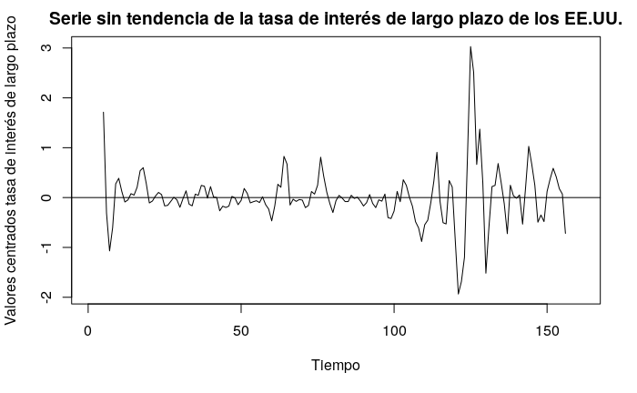

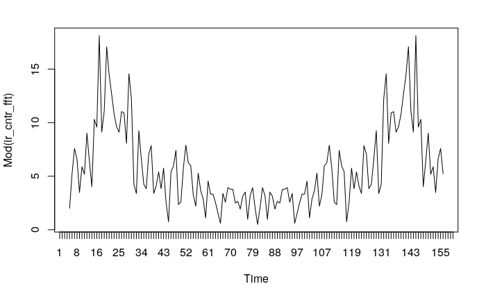

Al descomponer las tendencias largas podemos apreciar las oscilaciones de menor amplitud dentro de la serie de tasas de interés. Se puede observar que las oscilaciones de mayor frecuencia tienen poca amplitud, por lo que son oscilaciones ruidosas, que quitaremos de la serie, quedándonos sólo con las oscilaciones de menor frecuencia.

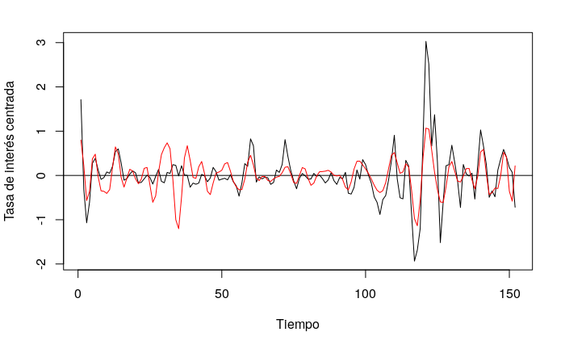

En este tipo de series no parece haber series de muy largo plazo que abarquen los siglos XIX y XX, sobre todo se introduce una distorsión en el siglo XX en el período de mayor inflación de los EE.UU.

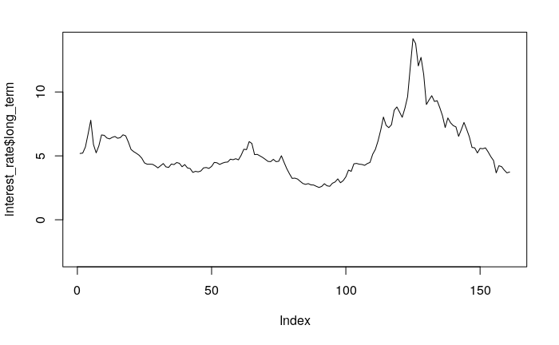

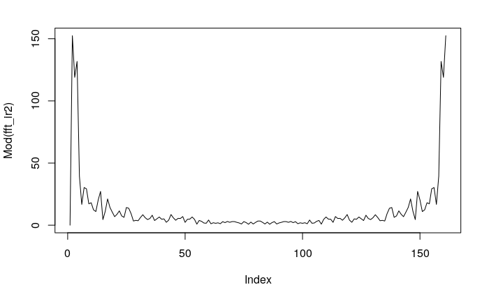

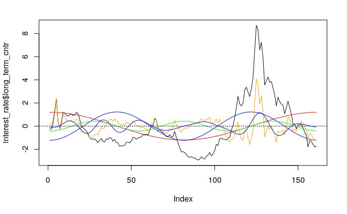

Revisando la capacidad explicativa de las primeras componentes de la transformada de Fourier

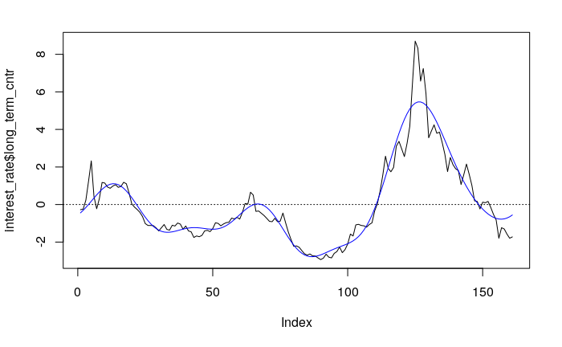

```
[1] 0.91142
```

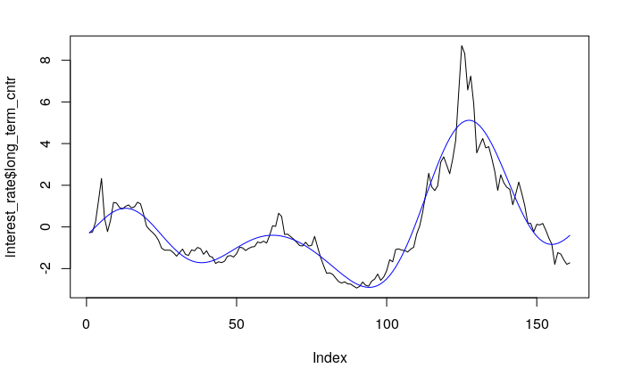

```
[1] 0.8924452
```